# I. Problem Description:

```python
IndAvenuedata.isnull().sum()
```

```
transaction_number          0
user_id                     0
payment_method              0
partner_id                  0
partner_category            0
country                     0
device_type                 0
money_transacted            0
transaction_initiation      0
partner_pricing_category    0
is_fraud                    0
dtype: int64
```

```python
# Understanding all columns
for col in IndAvenuedata.select_dtypes(include='object').columns:
    print(col)
    print(IndAvenuedata[col].unique())
```

```
payment_method
['sbi_atm_cum_debit_card' 'e_wallet_payments' 'other_debit_cards'
 'visa_master_debit_cards' 'visa_master_credit_cards'
 'unified_payments_interface']
partner_category
['cat_1' 'cat_2' 'cat_3' 'cat_4' 'cat_5' 'cat_6' 'cat_7' 'cat_8' 'cat_9']
country
['IND_INR']
device_type
['android_devices' 'other_pcs' 'windows_pcs' 'ios_devices']
transaction_initiation
['2016-11-15 19:16:12+00:00' '2017-01-11 09:25:33+00:00'
 '2016-12-07 07:58:09+00:00' ... '2016-12-26 21:47:08+00:00'
 '2016-12-11 13:44:06+00:00' '2017-01-11 19:08:18+00:00']
```

```python
print(IndAvenuedata["device_type"].value_counts())
print(IndAvenuedata["user_id"].value_counts())
print(IndAvenuedata["partner_id"].value_counts())
print("\n",IndAvenuedata["is_fraud"].value_counts())
print("\n",IndAvenuedata["payment_method"].value_counts())
```

```
other_pcs          45560
android_devices    29662
ios_devices          876
windows_pcs          431
Name: device_type, dtype: int64
53919649    3240
13205956    1656
418609      1530
1201216      623
16265089     622
            ...
567009         1
20539024       1
21613201       1
26347689       1
27952369       1
Name: user_id, Length: 3594, dtype: int64
47334     26105
23667     19526
78890     12273
118335     9546
7889       2317
31556      1892
165669     1216
86779      1121
149891      767
110446      640
102557      231
15778       189
157780      165
63112       159
189336      146
173558       89
55223        75
213003       25
39445        19
71001        15
126224       10
94668         2
181447        1
Name: partner_id, dtype: int64

 0    76375
1      154
Name: is_fraud, dtype: int64

 sbi_atm_cum_debit_card        30538
e_wallet_payments             27384
visa_master_debit_cards       11643
other_debit_cards              4495
visa_master_credit_cards       2454
unified_payments_interface       15
Name: payment_method, dtype: int64
```

```python
IndAvenuedata2=IndAvenuedata.drop(["transaction_number","country"],axis=1,inplace=True)
```

```python
IndAvenuedata.columns
```

```
Index(['user_id', 'payment_method', 'partner_id', 'partner_category',
       'device_type', 'money_transacted', 'transaction_initiation',
       'partner_pricing_category', 'is_fraud'],
      dtype='object')
```

```python
IndAvenuedata.dtypes
```

```
user_id                       int64
payment_method               object
partner_id                    int64
partner_category             object
device_type                  object
money_transacted            float64
transaction_initiation       object
partner_pricing_category      int64
is_fraud                      int64
dtype: object
```

```python
#converting data types
cat_attr=(["payment_method","partner_id","partner_category","device_type","partner_pricing_category","is_fraud"])
```

```python
for cols in cat_attr:
  IndAvenuedata[cols]=IndAvenuedata[cols].astype('category')
```

```python
IndAvenuedata.dtypes
```

```
user_id                        int64
payment_method              category
partner_id                  category
partner_category            category
device_type                 category
money_transacted             float64
transaction_initiation        object
partner_pricing_category    category
is_fraud                    category
dtype: object
```

```python
IndAvenuedata
```

|  | user_id | payment_method | partner_id | partner_category | device_type | money_transacted | transaction_initiation | partner_pricing_category | is_fraud |
| --- | --- | --- | --- | --- | --- | --- | --- | --- | --- |
| 0 | 17539344 | sbi_atm_cum_debit_card | 47334 | cat_1 | android_devices | -5.0 | 2016-11-15 19:16:12+00:00 | 2 | 0 |
| 1 | 24710841 | e_wallet_payments | 78890 | cat_2 | other_pcs | 100.0 | 2017-01-11 09:25:33+00:00 | 2 | 0 |
| 2 | 24265476 | e_wallet_payments | 78890 | cat_2 | other_pcs | 50.0 | 2016-12-07 07:58:09+00:00 | 2 | 0 |
| 3 | 10240000 | other_debit_cards | 102557 | cat_3 | other_pcs | 1000.0 | 2017-01-11 16:15:44+00:00 | 2 | 0 |
| 4 | 5880625 | other_debit_cards | 118335 | cat_1 | other_pcs | 200.0 | 2016-11-16 17:04:42+00:00 | 2 | 0 |
| ... | ... | ... | ... | ... | ... | ... | ... | ... | ... |
| 76524 | 19686969 | sbi_atm_cum_debit_card | 47334 | cat_1 | android_devices | -100.0 | 2016-11-30 13:40:45+00:00 | 2 | 0 |
| 76525 | 11662225 | visa_master_debit_cards | 118335 | cat_1 | other_pcs | 200.0 | 2017-01-08 08:35:31+00:00 | 2 | 0 |
| 76526 | 374544 | sbi_atm_cum_debit_card | 47334 | cat_1 | android_devices | -3.5 | 2016-12-26 21:47:08+00:00 | 2 | 0 |
| 76527 | 1687401 | sbi_atm_cum_debit_card | 47334 | cat_1 | android_devices | -20.0 | 2016-12-11 13:44:06+00:00 | 2 | 0 |
| 76528 | 6754801 | sbi_atm_cum_debit_card | 47334 | cat_1 | android_devices | -100.0 | 2017-01-11 19:08:18+00:00 | 2 | 0 |

76529 rows × 9 columns

LABEL ENCODING OF CATEGORICAL DATA

```python
# importing labelencoder
from sklearn.preprocessing import LabelEncoder
```

```python
le = LabelEncoder()
```

```python
IndAvenuedata['payment_method'] = le.fit_transform(IndAvenuedata['payment_method'])
IndAvenuedata['partner_category'] = le.fit_transform(IndAvenuedata['partner_category'])
IndAvenuedata['device_type'] = le.fit_transform(IndAvenuedata['device_type'])
IndAvenuedata.head()
```

|  | user_id | payment_method | partner_id | partner_category | device_type | money_transacted | transaction_initiation | partner_pricing_category | is_fraud |
| --- | --- | --- | --- | --- | --- | --- | --- | --- | --- |
| 0 | 17539344 | 2 | 47334 | 0 | 0 | -5.0 | 2016-11-15 19:16:12+00:00 | 2 | 0 |
| 1 | 24710841 | 0 | 78890 | 1 | 2 | 100.0 | 2017-01-11 09:25:33+00:00 | 2 | 0 |
| 2 | 24265476 | 0 | 78890 | 1 | 2 | 50.0 | 2016-12-07 07:58:09+00:00 | 2 | 0 |
| 3 | 10240000 | 1 | 102557 | 2 | 2 | 1000.0 | 2017-01-11 16:15:44+00:00 | 2 | 0 |
| 4 | 5880625 | 1 | 118335 | 0 | 2 | 200.0 | 2016-11-16 17:04:42+00:00 | 2 | 0 |

FEATURE ENGINNERING TO THE TRANSACTION INITIATION: (featuring engineering is a good way to enhance predictive models)

```python
IndAvenuedata
```

|  | user_id | payment_method | partner_id | partner_category | device_type | money_transacted | transaction_initiation | partner_pricing_category | is_fraud |
| --- | --- | --- | --- | --- | --- | --- | --- | --- | --- |
| 0 | 17539344 | 2 | 47334 | 0 | 0 | -5.0 | 2016-11-15 19:16:12+00:00 | 2 | 0 |
| 1 | 24710841 | 0 | 78890 | 1 | 2 | 100.0 | 2017-01-11 09:25:33+00:00 | 2 | 0 |
| 2 | 24265476 | 0 | 78890 | 1 | 2 | 50.0 | 2016-12-07 07:58:09+00:00 | 2 | 0 |
| 3 | 10240000 | 1 | 102557 | 2 | 2 | 1000.0 | 2017-01-11 16:15:44+00:00 | 2 | 0 |
| 4 | 5880625 | 1 | 118335 | 0 | 2 | 200.0 | 2016-11-16 17:04:42+00:00 | 2 | 0 |
| ... | ... | ... | ... | ... | ... | ... | ... | ... | ... |
| 76524 | 19686969 | 2 | 47334 | 0 | 0 | -100.0 | 2016-11-30 13:40:45+00:00 | 2 | 0 |
| 76525 | 11662225 | 5 | 118335 | 0 | 2 | 200.0 | 2017-01-08 08:35:31+00:00 | 2 | 0 |
| 76526 | 374544 | 2 | 47334 | 0 | 0 | -3.5 | 2016-12-26 21:47:08+00:00 | 2 | 0 |
| 76527 | 1687401 | 2 | 47334 | 0 | 0 | -20.0 | 2016-12-11 13:44:06+00:00 | 2 | 0 |
| 76528 | 6754801 | 2 | 47334 | 0 | 0 | -100.0 | 2017-01-11 19:08:18+00:00 | 2 | 0 |

76529 rows × 9 columns

```python
IndAvenuedata['transaction_initiation']=IndAvenuedata['transaction_initiation'].apply(pd.to_datetime)
IndAvenuedata['transaction_initiation_year'] = IndAvenuedata['transaction_initiation'].dt.year
IndAvenuedata['transaction_initiation_month'] = IndAvenuedata['transaction_initiation'].dt.month
IndAvenuedata['transaction_initiation_week'] = IndAvenuedata['transaction_initiation'].dt.isocalendar().week
IndAvenuedata['transaction_initiation_day'] = IndAvenuedata['transaction_initiation'].dt.day
IndAvenuedata['transaction_initiation_hour'] = IndAvenuedata['transaction_initiation'].dt.hour
IndAvenuedata['transaction_initiation_minute'] = IndAvenuedata['transaction_initiation'].dt.minute
IndAvenuedata['transaction_initiation_dayofweek'] = IndAvenuedata['transaction_initiation'].dt.dayofweek
IndAvenuedata=IndAvenuedata.drop(['transaction_initiation'],axis=1)
IndAvenuedata.head()
```

|  | user_id | payment_method | partner_id | partner_category | device_type | money_transacted | partner_pricing_category | is_fraud | transaction_initiation_year | transaction_initiation_month | transaction_initiation_week | transaction_initiation_day | transaction_initiation_hour | transaction_initiation_minute | transaction_initiation_dayofweek |
| --- | --- | --- | --- | --- | --- | --- | --- | --- | --- | --- | --- | --- | --- | --- | --- |
| 0 | 17539344 | 2 | 47334 | 0 | 0 | -5.0 | 2 | 0 | 2016 | 11 | 46 | 15 | 19 | 16 | 1 |
| 1 | 24710841 | 0 | 78890 | 1 | 2 | 100.0 | 2 | 0 | 2017 | 1 | 2 | 11 | 9 | 25 | 2 |
| 2 | 24265476 | 0 | 78890 | 1 | 2 | 50.0 | 2 | 0 | 2016 | 12 | 49 | 7 | 7 | 58 | 2 |
| 3 | 10240000 | 1 | 102557 | 2 | 2 | 1000.0 | 2 | 0 | 2017 | 1 | 2 | 11 | 16 | 15 | 2 |
| 4 | 5880625 | 1 | 118335 | 0 | 2 | 200.0 | 2 | 0 | 2016 | 11 | 46 | 16 | 17 | 4 | 2 |

```python
IndAvenuedata.shape
```

```
(76529, 15)
```

```python
IndAvenuedata.columns
```

```
Index(['user_id', 'payment_method', 'partner_id', 'partner_category',
       'device_type', 'money_transacted', 'partner_pricing_category',
       'is_fraud', 'transaction_initiation_year',
       'transaction_initiation_month', 'transaction_initiation_week',
       'transaction_initiation_day', 'transaction_initiation_hour',
       'transaction_initiation_minute', 'transaction_initiation_dayofweek'],
      dtype='object')
```

**LOGISTIC REGRESSION** (a statistical analysis method to predict a binary outcome, such as yes or no, based on prior observations of a data set

```python
X = IndAvenuedata.drop("is_fraud", axis=1)
print(X.shape)
X.head()
```

```
(76529, 14)
```

|  | user_id | payment_method | partner_id | partner_category | device_type | money_transacted | partner_pricing_category | transaction_initiation_year | transaction_initiation_month | transaction_initiation_week | transaction_initiation_day | transaction_initiation_hour | transaction_initiation_minute | transaction_initiation_dayofweek |
| --- | --- | --- | --- | --- | --- | --- | --- | --- | --- | --- | --- | --- | --- | --- |
| 0 | 17539344 | 2 | 47334 | 0 | 0 | -5.0 | 2 | 2016 | 11 | 46 | 15 | 19 | 16 | 1 |
| 1 | 24710841 | 0 | 78890 | 1 | 2 | 100.0 | 2 | 2017 | 1 | 2 | 11 | 9 | 25 | 2 |
| 2 | 24265476 | 0 | 78890 | 1 | 2 | 50.0 | 2 | 2016 | 12 | 49 | 7 | 7 | 58 | 2 |
| 3 | 10240000 | 1 | 102557 | 2 | 2 | 1000.0 | 2 | 2017 | 1 | 2 | 11 | 16 | 15 | 2 |
| 4 | 5880625 | 1 | 118335 | 0 | 2 | 200.0 | 2 | 2016 | 11 | 46 | 16 | 17 | 4 | 2 |

```python
y= IndAvenuedata['is_fraud']
print(y.shape)
y.head()
```

```
(76529,)
```

```
0    0
1    0
2    0
3    0
4    0
Name: is_fraud, dtype: category
Categories (2, int64): [0, 1]
```

TRAIN TEST SPLIT

```python
from sklearn.model_selection import train_test_split
X_train,X_test,y_train,y_test = train_test_split(X,y,test_size = 0.20,random_state=143)
```

```python
from sklearn.linear_model import LogisticRegression

lg = LogisticRegression()

lg.fit(X_train,y_train)

y_train_pred = lg.predict(X_train)
y_test_pred = lg.predict(X_test)


print(y_train_pred)
print(y_test_pred)
```

```
[0 0 0 ... 0 0 0]
[0 0 0 ... 0 0 0]
```

```python
y_train_pred = lg.predict(X_train)
y_test_pred = lg.predict(X_test)
```

```python
from sklearn.metrics import classification_report
print(classification_report(y_test, y_test_pred))
```

```
              precision    recall  f1-score   support

           0       1.00      1.00      1.00     15272
           1       0.71      0.29      0.42        34

    accuracy                           1.00     15306
   macro avg       0.86      0.65      0.71     15306
weighted avg       1.00      1.00      1.00     15306
```

From logistic regression we are not get good result so moving to another ensemble classifer that works realy well for this kind of data

**RANDOM FOREST** (creates a set of decision trees from a randomly selected subset of the training set. )

```python
# impoting random forest classifier
from sklearn.ensemble import RandomForestClassifier
rfc = RandomForestClassifier(max_depth=5,random_state=143,max_leaf_nodes=50)
```

```python
rfc.fit(X_train,y_train)
```

```
RandomForestClassifier(max_depth=5, max_leaf_nodes=50, random_state=143)
```

```python
## importing classification_report
from sklearn.metrics import classification_report
```

```python
## predicting x_train and y_tarin
y_train_pred = rfc.predict(X_train)
y_test_pred = rfc.predict(X_test)
```

```python
print(classification_report(y_test, y_test_pred))
```

```
              precision    recall  f1-score   support

           0       1.00      1.00      1.00     15272
           1       1.00      0.59      0.74        34

    accuracy                           1.00     15306
   macro avg       1.00      0.79      0.87     15306
weighted avg       1.00      1.00      1.00     15306
```

```python
# f1_score
f1_score(y_test,y_test_pred)
```

```
0.7407407407407407
```

```python
from sklearn.metrics import recall_score, precision_score, f1_score
```

```python
#validating on train
print('recall_score for train',recall_score(y_train,y_train_pred))
print('precision_score for train',precision_score(y_train,y_train_pred))
print('f1_score for train',f1_score(y_train,y_train_pred))
```

```
recall_score for train 0.7416666666666667
precision_score for train 0.9888888888888889
f1_score for train 0.8476190476190477
```

```python
# validate on test
print('recall_score for test',recall_score(y_test,y_test_pred))
print('precision_score for test',precision_score(y_test,y_test_pred))
print('f1_score for test',f1_score(y_test,y_test_pred))
```

```
recall_score for test 0.5882352941176471
precision_score for test 1.0
f1_score for test 0.7407407407407407
```

```
Index(['money_transacted', 'user_id', 'partner_pricing_category',
       'transaction_initiation_day', 'partner_id',
       'transaction_initiation_minute', 'payment_method',
       'transaction_initiation_dayofweek', 'transaction_initiation_week',
       'partner_category', 'transaction_initiation_hour',
       'transaction_initiation_month', 'transaction_initiation_year',
       'device_type'],
      dtype='object')
```

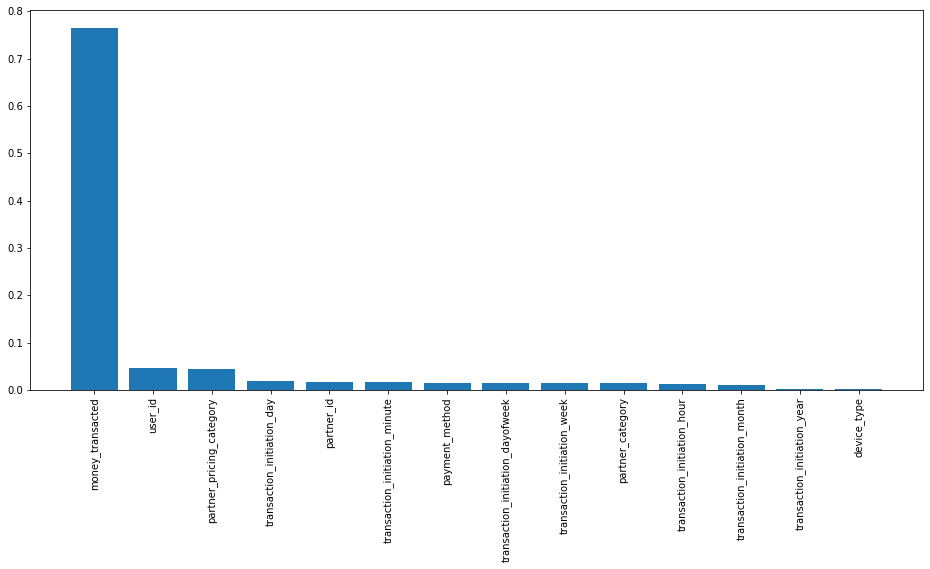

```python
# finding important independent variable
plt.figure(1, figsize=(16, 7))
plt.bar(imp.index, imp["Gini-importance"])
plt.xticks(imp.index, rotation=90)
print(imp.index)
```

```
Money transacted plays a key role in fraud detection
```

**DECISION TREE** (A Decision tree is a flowchart-like tree structure, where each internal node denotes a test on an attribute, each branch represents an outcome of the test, and each leaf node (terminal node) holds a class label.)

```python
from sklearn.tree import DecisionTreeClassifier
```

```python
dtc=DecisionTreeClassifier()
```

```python
dtc.fit(X_train,y_train)
```

```
DecisionTreeClassifier()
```

```python
## predicting x_train and y_tarin
y_train_pred = dtc.predict(X_train)
y_test_pred = dtc.predict(X_test)
```

```python
print(classification_report(y_test, y_test_pred))
```

```
              precision    recall  f1-score   support

           0       1.00      1.00      1.00     15272
           1       0.87      0.79      0.83        34

    accuracy                           1.00     15306
   macro avg       0.94      0.90      0.92     15306
weighted avg       1.00      1.00      1.00     15306
```

```python
# f1_score
f1_score(y_test,y_test_pred)
```

```
0.8307692307692308
```

```python
from sklearn.metrics import recall_score, precision_score, f1_score
```

```python
#validating on train
print('recall_score for train',recall_score(y_train,y_train_pred))
print('precision_score for train',precision_score(y_train,y_train_pred))
print('f1_score for train',f1_score(y_train,y_train_pred))
```

```
recall_score for train 1.0
precision_score for train 1.0
f1_score for train 1.0
```

```python
# validate on test
print('recall_score for test',recall_score(y_test,y_test_pred))
print('precision_score for test',precision_score(y_test,y_test_pred))
print('f1_score for test',f1_score(y_test,y_test_pred))
```

```
recall_score for test 0.7941176470588235
precision_score for test 0.8709677419354839
f1_score for test 0.8307692307692308
```

**KNN** (The KNN algorithm assumes that similar things exist in close proximity. In other words, similar things are near to each other)

```python
from sklearn.neighbors import KNeighborsClassifier
```

```python
knn=KNeighborsClassifier()
```

```python
knn.fit(X_train,y_train)
```

```
KNeighborsClassifier()
```

```python
## predicting x_train and y_tarin
y_train_pred = dtc.predict(X_train)
y_test_pred = dtc.predict(X_test)
```

```python
print(classification_report(y_test, y_test_pred))
```

```
              precision    recall  f1-score   support

           0       1.00      1.00      1.00     15272
           1       0.87      0.79      0.83        34

    accuracy                           1.00     15306
   macro avg       0.94      0.90      0.92     15306
weighted avg       1.00      1.00      1.00     15306
```

```python
# f1_score
f1_score(y_test,y_test_pred)
```

```
0.8307692307692308
```

```python
#validating on train
print('recall_score for train',recall_score(y_train,y_train_pred))
print('precision_score for train',precision_score(y_train,y_train_pred))
print('f1_score for train',f1_score(y_train,y_train_pred))
```

```
recall_score for train 1.0
precision_score for train 1.0
f1_score for train 1.0
```

```python
# validate on test
print('recall_score for test',recall_score(y_test,y_test_pred))
print('precision_score for test',precision_score(y_test,y_test_pred))
print('f1_score for test',f1_score(y_test,y_test_pred))
```

```
recall_score for test 0.7941176470588235
precision_score for test 0.8709677419354839
f1_score for test 0.8307692307692308
```

[output not shown]

**TEST DATASET**

```python
IndAvenuedata1=pd.read_csv('/content/test_data-1611220982388.csv',na_values="?"",")
```

```python
IndAvenuedata1.shape
```

```
(19133, 10)
```

```python
IndAvenuedata1.head()
```

|  | transaction_number | user_id | payment_method | partner_id | partner_category | country | device_type | money_transacted | transaction_initiation | partner_pricing_category |
| --- | --- | --- | --- | --- | --- | --- | --- | --- | --- | --- |
| 0 | 857050141038272 | 3802500 | visa_master_debit_cards | 118335 | cat_1 | IND_INR | other_pcs | 200.0 | 2016-12-28 14:44:37+00:00 | 2 |
| 1 | 4400462872603 | 200704 | e_wallet_payments | 23667 | cat_2 | IND_INR | other_pcs | 20.0 | 2016-12-14 17:49:48+00:00 | 2 |
| 2 | 1207915598569499 | 25150225 | sbi_atm_cum_debit_card | 47334 | cat_1 | IND_INR | android_devices | -100.0 | 2017-01-21 10:18:11+00:00 | 2 |
| 3 | 2009725616777536 | 21827584 | visa_master_credit_cards | 78890 | cat_2 | IND_INR | other_pcs | 200.0 | 2017-01-16 13:25:10+00:00 | 1 |
| 4 | 2319205210274863 | 576081 | e_wallet_payments | 23667 | cat_2 | IND_INR | other_pcs | 100.0 | 2017-02-09 12:47:28+00:00 | 2 |

```python
#what are the datatypes
IndAvenuedata1.dtypes
```

```
transaction_number            int64
user_id                       int64
payment_method               object
partner_id                    int64
partner_category             object
country                      object
device_type                  object
money_transacted            float64
transaction_initiation       object
partner_pricing_category      int64
dtype: object
```

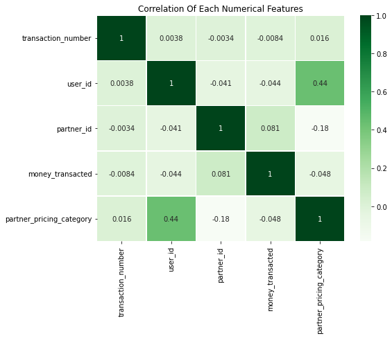

```python
plt.figure(figsize=(8,6))
sns.heatmap(IndAvenuedata1.corr(),linewidths=0.4,square=False,cmap='Greens',annot=True)
plt.title("Correlation Of Each Numerical Features")
plt.show()
```

```python
IndAvenuedata1.isnull().sum()
```

```
transaction_number          0
user_id                     0
payment_method              0
partner_id                  0
partner_category            0
country                     0
device_type                 0
money_transacted            0
transaction_initiation      0
partner_pricing_category    0
dtype: int64
```

```python
cat_attr=(["payment_method","partner_id","partner_category","device_type","partner_pricing_category"])
```

```python
for cols in cat_attr:
  IndAvenuedata1[cols]=IndAvenuedata[cols].astype('category')
```

```python
IndAvenuedata1['payment_method'] = le.fit_transform(IndAvenuedata1['payment_method'])
IndAvenuedata1['partner_category'] = le.fit_transform(IndAvenuedata1['partner_category'])
IndAvenuedata1['device_type'] = le.fit_transform(IndAvenuedata1['device_type'])
IndAvenuedata1.head()
```

|  | transaction_number | user_id | payment_method | partner_id | partner_category | country | device_type | money_transacted | transaction_initiation | partner_pricing_category |
| --- | --- | --- | --- | --- | --- | --- | --- | --- | --- | --- |
| 0 | 857050141038272 | 3802500 | 2 | 47334 | 0 | IND_INR | 0 | 200.0 | 2016-12-28 14:44:37+00:00 | 2 |
| 1 | 4400462872603 | 200704 | 0 | 78890 | 1 | IND_INR | 2 | 20.0 | 2016-12-14 17:49:48+00:00 | 2 |
| 2 | 1207915598569499 | 25150225 | 0 | 78890 | 1 | IND_INR | 2 | -100.0 | 2017-01-21 10:18:11+00:00 | 2 |
| 3 | 2009725616777536 | 21827584 | 1 | 102557 | 2 | IND_INR | 2 | 200.0 | 2017-01-16 13:25:10+00:00 | 2 |
| 4 | 2319205210274863 | 576081 | 1 | 118335 | 0 | IND_INR | 2 | 100.0 | 2017-02-09 12:47:28+00:00 | 2 |

```python
IndAvenuedata1['transaction_initiation']=IndAvenuedata1['transaction_initiation'].apply(pd.to_datetime)
IndAvenuedata1['transaction_initiation_year'] = IndAvenuedata1['transaction_initiation'].dt.year
IndAvenuedata1['transaction_initiation_month'] = IndAvenuedata1['transaction_initiation'].dt.month
IndAvenuedata1['transaction_initiation_week'] = IndAvenuedata1['transaction_initiation'].dt.isocalendar().week
IndAvenuedata1['transaction_initiation_day'] = IndAvenuedata1['transaction_initiation'].dt.day
IndAvenuedata1['transaction_initiation_hour'] = IndAvenuedata1['transaction_initiation'].dt.hour
IndAvenuedata1['transaction_initiation_minute'] = IndAvenuedata1['transaction_initiation'].dt.minute
IndAvenuedata1['transaction_initiation_dayofweek'] = IndAvenuedata1['transaction_initiation'].dt.dayofweek
IndAvenuedata1=IndAvenuedata1.drop(['transaction_initiation'],axis=1)
IndAvenuedata1.head()
```

|  | transaction_number | user_id | payment_method | partner_id | partner_category | country | device_type | money_transacted | partner_pricing_category | transaction_initiation_year | transaction_initiation_month | transaction_initiation_week | transaction_initiation_day | transaction_initiation_hour | transaction_initiation_minute | transaction_initiation_dayofweek |
| --- | --- | --- | --- | --- | --- | --- | --- | --- | --- | --- | --- | --- | --- | --- | --- | --- |
| 0 | 857050141038272 | 3802500 | 2 | 47334 | 0 | IND_INR | 0 | 200.0 | 2 | 2016 | 12 | 52 | 28 | 14 | 44 | 2 |
| 1 | 4400462872603 | 200704 | 0 | 78890 | 1 | IND_INR | 2 | 20.0 | 2 | 2016 | 12 | 50 | 14 | 17 | 49 | 2 |
| 2 | 1207915598569499 | 25150225 | 0 | 78890 | 1 | IND_INR | 2 | -100.0 | 2 | 2017 | 1 | 3 | 21 | 10 | 18 | 5 |
| 3 | 2009725616777536 | 21827584 | 1 | 102557 | 2 | IND_INR | 2 | 200.0 | 2 | 2017 | 1 | 3 | 16 | 13 | 25 | 0 |
| 4 | 2319205210274863 | 576081 | 1 | 118335 | 0 | IND_INR | 2 | 100.0 | 2 | 2017 | 2 | 6 | 9 | 12 | 47 | 3 |

```python
IndAvenuedata1
```

|  | transaction_number | user_id | payment_method | partner_id | partner_category | country | device_type | money_transacted | partner_pricing_category | transaction_initiation_year | transaction_initiation_month | transaction_initiation_week | transaction_initiation_day | transaction_initiation_hour | transaction_initiation_minute | transaction_initiation_dayofweek |
| --- | --- | --- | --- | --- | --- | --- | --- | --- | --- | --- | --- | --- | --- | --- | --- | --- |
| 0 | 857050141038272 | 3802500 | 2 | 47334 | 0 | IND_INR | 0 | 200.0 | 2 | 2016 | 12 | 52 | 28 | 14 | 44 | 2 |
| 1 | 4400462872603 | 200704 | 0 | 78890 | 1 | IND_INR | 2 | 20.0 | 2 | 2016 | 12 | 50 | 14 | 17 | 49 | 2 |
| 2 | 1207915598569499 | 25150225 | 0 | 78890 | 1 | IND_INR | 2 | -100.0 | 2 | 2017 | 1 | 3 | 21 | 10 | 18 | 5 |
| 3 | 2009725616777536 | 21827584 | 1 | 102557 | 2 | IND_INR | 2 | 200.0 | 2 | 2017 | 1 | 3 | 16 | 13 | 25 | 0 |
| 4 | 2319205210274863 | 576081 | 1 | 118335 | 0 | IND_INR | 2 | 100.0 | 2 | 2017 | 2 | 6 | 9 | 12 | 47 | 3 |
| ... | ... | ... | ... | ... | ... | ... | ... | ... | ... | ... | ... | ... | ... | ... | ... | ... |
| 19128 | 5332775378111 | 13235044 | 0 | 23667 | 1 | IND_INR | 2 | 20.0 | 2 | 2017 | 1 | 52 | 1 | 13 | 2 | 6 |
| 19129 | 939262915465237 | 12257001 | 4 | 31556 | 1 | IND_INR | 2 | 30.0 | 1 | 2016 | 12 | 52 | 26 | 19 | 41 | 0 |
| 19130 | 18324574916544 | 5958481 | 0 | 23667 | 1 | IND_INR | 2 | 20.0 | 2 | 2016 | 12 | 51 | 24 | 4 | 29 | 5 |
| 19131 | 893473728055875 | 53919649 | 0 | 7889 | 1 | IND_INR | 2 | -500.0 | 2 | 2016 | 12 | 48 | 4 | 15 | 38 | 6 |
| 19132 | 84390778936647 | 14500864 | 0 | 78890 | 1 | IND_INR | 2 | 40.0 | 2 | 2017 | 1 | 2 | 12 | 21 | 24 | 3 |

19133 rows × 16 columns

```python
IndAvenuedata1.drop(["transaction_number","country"],axis=1,inplace=True)
```

```python
IndAvenuedata1.shape
```

```
(19133, 14)
```

```python
prediction= dtc.predict(IndAvenuedata1)
```

```python
print(prediction)
```

```
[0 0 0 ... 0 0 0]
```

```python
import numpy as np
import pandas as pd
prediction = pd.DataFrame(prediction, columns=['predictions']).to_csv('prediction.csv')
```

What are your recommendations for IndAvenue?

```
money_transacted is very high so we can increase processing fees
```

Any final visualizations you would use to convey your recommendations?

```
by finding independent variable importance
```

Which simple strategies would you use to ensure fast customer checkout?

```
by using DECISION TREE model
```